## title: Compare transpiler settings description: explore the transpilation pipeline through the full process of creating, transpiling, and submitting circuits.

# Compare transpiler settings

{/* DO NOT EDIT THIS CELL!!! This cell's content is generated automatically by a script. Anything you add here will be removed next time the notebook is run. To add new content, create a new cell before or after this one. */}

The code on this page was developed using the following requirements. We recommend using these versions or newer.

````
```
qiskit[all]~=2.4.0
qiskit-ibm-runtime~=0.46.1
```
````

Different transpiler settings provide different types of optimization to the circuit, often at the expense of longer classical processing time. This guide walks through the full process of creating, transpiling, and submitting circuits to demonstrate testing the performance of various settings.

Note that the same setting could improve the results of one circuit while hindering another. Be sure to inspect the resulting transpiled circuits before running on actual hardware.

## Set up and create sample circuit

```python
# Create circuit to test transpiler on
from qiskit import QuantumCircuit
from qiskit.transpiler.preset_passmanagers import generate_preset_pass_manager
from qiskit.circuit.library import grover_operator, DiagonalGate

# Use Statevector object to calculate the ideal output
from qiskit.quantum_info import Statevector
from qiskit.visualization import plot_histogram
from qiskit.transpiler import PassManager

from qiskit.circuit.library import XGate
from qiskit.quantum_info import hellinger_fidelity
```

Create a small circuit for the transpiler to try to optimize. This example creates a circuit that carries out Grover's algorithm with an oracle that marks the state `111`. Next, simulate the ideal distribution (what you'd expect to measure if you ran this on a perfect quantum computer an infinite number of times) for comparison later.

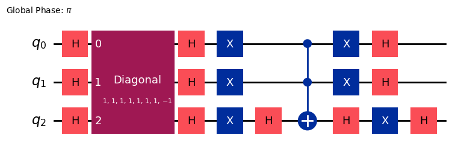

```python
oracle = DiagonalGate([1] * 7 + [-1])
qc = QuantumCircuit(3)
qc.h([0, 1, 2])
qc = qc.compose(grover_operator(oracle))

qc.draw(output="mpl", style="iqp")
```

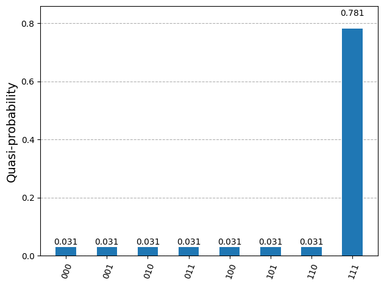

```python
ideal_distribution = Statevector.from_instruction(qc).probabilities_dict()

plot_histogram(ideal_distribution)
```

## Transpile

Next, transpile the circuits for the QPU. You will compare the performance of the transpiler with `optimization_level` set to `0` (lowest) against `3` (highest). The lowest optimization level does the bare minimum needed to get the circuit running on the device; it maps the circuit qubits to the device qubits and adds swap gates to allow all two-qubit operations. The highest optimization level is much smarter and uses lots of tricks to reduce the overall gate count. Since multi-qubit gates have high error rates and qubits decohere over time, the shorter circuits should give better results.

This example uses IBM Quantum® hardware, but you can try it on any Qiskit-compatible QPU. Your results might be different.

The following cell transpiles `qc` for both values of `optimization_level`, prints the number of two-qubit gates, and adds the transpiled circuits to a list. Some of the transpiler's algorithms are randomized, so it sets a seed for reproducibility.

```python
# Use Qiskit Runtime to run jobs on hardware
from qiskit_ibm_runtime import (
    QiskitRuntimeService,
    SamplerV2 as Sampler,
)
```

```python
# Select the backend with the fewest number of jobs in the queue
service = QiskitRuntimeService(channel="ibm_quantum_platform")
backend = service.least_busy(
    operational=True, simulator=False, min_num_qubits=127
)
backend.name
```

```
'ibm_marrakesh'
```

```python
# Need to add measurements to the circuit
qc.measure_all()

# Find the correct two-qubit gate
twoQ_gates = set(["ecr", "cz", "cx"])
for gate in backend.basis_gates:
    if gate in twoQ_gates:
        twoQ_gate = gate

circuits = []
for optimization_level in [0, 3]:
    pm = generate_preset_pass_manager(
        optimization_level, backend=backend, seed_transpiler=0
    )
    t_qc = pm.run(qc)
    print(
        f"Two-qubit gates (optimization_level={optimization_level}): ",
        t_qc.count_ops()[twoQ_gate],
    )
    circuits.append(t_qc)
```

```
Two-qubit gates (optimization_level=0):  21
Two-qubit gates (optimization_level=3):  12
```

Since CNOTs usually have a high error rate, the circuit transpiled with `optimization_level=3` should perform much better.

Another way you can improve performance is through dynamical decoupling, by applying a sequence of gates to idling qubits. This cancels out some unwanted interactions with the environment. The following cell adds dynamic decoupling to the circuit transpiled with `optimization_level=3` and adds it to the list.

```python
from qiskit_ibm_runtime.transpiler.passes.scheduling import (
    ASAPScheduleAnalysis,
    PadDynamicalDecoupling,
)

# Get gate durations so the transpiler knows how long each operation takes
durations = backend.target.durations()

# This is the sequence we'll apply to idling qubits
dd_sequence = [XGate(), XGate()]

# Run scheduling and dynamic decoupling passes on circuit
pm = PassManager(
    [
        ASAPScheduleAnalysis(durations),
        PadDynamicalDecoupling(durations, dd_sequence),
    ]
)
circ_dd = pm.run(circuits[1])

# Add this new circuit to our list
circuits.append(circ_dd)
```

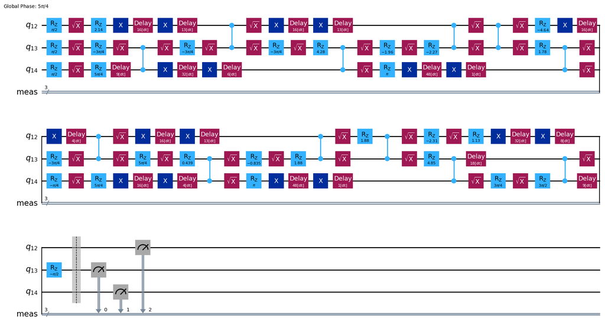

```python
circ_dd.draw(output="mpl", style="iqp", idle_wires=False)
```

## Execute the circuit

At this point, you have a list of circuits transpiled with different settings. Next, run these circuits using the Sampler primitive and store the results to `result`.

```python
sampler = Sampler(backend)
job = sampler.run(
    [(circuit) for circuit in circuits],  # sample all three circuits
    shots=8000,
)
result = job.result()
```

## View results

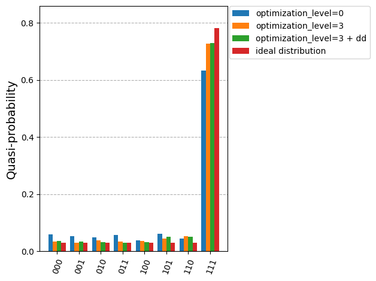

```python
binary_prob = [
    {
        k: v / res.data.meas.num_shots
        for k, v in res.data.meas.get_counts().items()
    }
    for res in result
]
plot_histogram(
    binary_prob + [ideal_distribution],
    bar_labels=False,
    legend=[
        "optimization_level=0",
        "optimization_level=3",
        "optimization_level=3 + dd",
        "ideal distribution",
    ],
)
```

You can confirm this by computing the Hellinger fidelity between each set of results and the ideal distribution (higher is better, and 1 is perfect fidelity).

```python
for prob in binary_prob:
    print(f"{hellinger_fidelity(prob, ideal_distribution):.3f}")
```

```
0.972
0.994
0.994
```

## Next steps

* Explore some advanced transpilation resources, such as:

```
* [Write a custom transpiler pass](/docs/guides/custom-transpiler-pass)
* [Create and transpile against custom backends](/docs/guides/custom-backend)
* [Install and use transpiler plugins](/docs/guides/transpiler-plugins)
```

* Browse the available tutorials.

© IBM Corp., 2017-2026